# Figures for “Perturbed progenitor cell behavior and YAP mediated expansion drives EML1-linked cerebral cortical malformation in a human forebrain organoid model.”

Anne Hoffrichter

2021/07/12

```r
library(Seurat)
library(tidyverse)
library(patchwork)
library(org.Hs.eg.db)
library(GO.db)
options(stringsAsFactors = FALSE)
set.seed(42)
```

```r
data <- readRDS("../data/integrated_data.rds")
DefaultAssay(data) <- "RNA"
```

```r
my_levels <- c("RG1", "RG to bRG", "RG2", "IP", "YN", "MLC")
Idents(data) <- factor(Idents(data), levels = my_levels)
```

# 1 Figure 2 - ScRNA-seq reveals cellular identity of ectopic cells in EML1-KO cerebral organoids

## 1.1 a) Dimensional reduction plot (UMAP)

scRNA-seq of 2,335 control and 3,358 EML1-KO cells (3 pooled independent batches, 3 organoids each). Cells shown in UMAP plot and colored by annotated cell type.

```r
a <- subset(data, KO == "CTRL") %>% DimPlot(pt.size = 0.2) + ggtitle("Control") +
    NoLegend() + theme(plot.title = element_text(face = "plain", size = 20, hjust = 0.5))
b <- subset(data, KO == "KO") %>% DimPlot(pt.size = 0.2) + ggtitle(substitute(paste(italic("EML1"),
    "-KO"))) + theme(plot.title = element_text(face = "plain", size = 20, hjust = 0.5))
```

## 1.2 b) DotPlot - marker genes for specifying cell types

Dotplot of known marker gene expression in control-derived cells. Scaled average normalized expression for the respective gene in each cell type is indicated by a continuous color scale. Number of cells in the respective cluster expressing the genes is represented by the size of the dots.

```r
genes <- c("CDH2", "C1orf61", "FABP7", "HES1", "VIM", "SOX2", "NES", "OTX2", "PAX6",
    "EMX2", "SFRP1", "ANXA5", "PTPRZ1", "GSN", "FABP5", "LUM", "DCN", "COL5A1", "NEUROD1",
    "EOMES", "ELAVL4", "NHLH1", "MEIS2", "POU3F2", "TBR1", "MAPT", "STMN1", "DCX",
    "SNAP25")
```

```r
my_levels <- c("MLC", "YN", "IP", "RG2", "RG to bRG", "RG1")
Idents(data) <- factor(Idents(data), levels = my_levels)


c <- subset(data, KO == "CTRL") %>% DotPlot(features = genes, cols = c("lightgrey",
    "#DA5B51")) + theme_classic(base_size = 13) + RotatedAxis() + theme(plot.title = element_text(hjust = 0.5,
    face = "plain"), axis.title = element_blank(), legend.text = element_text(size = 8),
    legend.title = element_text(size = 8), legend.key.size = unit(0.3, "cm")) + guides(color = guide_colorbar(title = "Average\nExpression"),
    size = guide_legend(title = "Percent\nExpressed")) + geom_vline(xintercept = c(10.5,
    15.5, 18.5, 22.5), linetype = "dotted", size = 0.5)
```

## 1.3 c) percent cells per cell type Ctrl vs. KO without MLC

Comparison of cell-type composition between control and EML1-KO. Numbers indicate percentage of total cells belonging to the respective cell-type.

```r
my_levels <- rev(my_levels)
Idents(data) <- factor(Idents(data), levels = my_levels)
data_subset <- subset(data, cell_type != "MLC")

Ctrl <- subset(data_subset, KO == "CTRL")
KO <- subset(data_subset, KO == "KO")
Idents(Ctrl) <- factor(Idents(Ctrl), levels = my_levels)
Idents(KO) <- factor(Idents(KO), levels = my_levels)
tCtrl <- table(Ctrl$cell_type)
tKO <- table(KO$cell_type)
df <- data.frame(tCtrl, tKO)
df <- df[c(1:4, 6), c(1:2, 4)]

colnames(df) <- c("cell_type", "Control", "KO")
pct_Ctrl <- round(df$Control/sum(df$Control) * 100, digits = 1)
pct_KO <- round(df$KO/sum(df$KO) * 100, digits = 1)
pct <- data.frame(pct_Ctrl, pct_KO, row.names = df$cell_type)
pct2 <- data.frame(KO = "Control", pct = pct$pct_Ctrl, cell_type = rownames(pct))
pct3 <- data.frame(KO = "KO", pct = pct$pct_KO, cell_type = rownames(pct))
pct4 <- rbind(pct2, pct3)
pct4$cell_type <- ordered(pct4$cell_type, levels = my_levels[1:5])
```

```r
d <- ggplot(data = pct4, aes(x = cell_type, y = pct, fill = KO)) + geom_bar(stat = "identity",
    position = position_dodge2(reverse = T)) + coord_flip() + geom_text(aes(label = paste0(pct,
    " %")), hjust = -0.1, color = "black", position = position_dodge2(0.9, reverse = T),
    size = 3) + theme_minimal(base_size = 13) + scale_x_discrete(limits = rev(levels(pct4$cell_type))) +
    theme(axis.text = element_text(colour = "black", face = "plain")) + scale_fill_manual(values = c("#DA5B51",
    "#00A5AA"), labels = c("Control", substitute(paste(italic("EML1"), "-KO")))) +
    ylim(0, 65) + labs(x = "", y = "", fill = c("Control", substitute(paste(italic("EML1"),
    "-KO")))) + labs(fill = "")
```

## 1.4 Figure 2 panel a & b & c

```r
a + c + b + d + plot_layout(widths = c(1, 2))
```

[figure not shown]

## 1.5 d) & i) MEIS2, COL1A2, COL3A1, LUM violin plots without MLCs

Normalized expression values of MEIS2 and COL1A2 per cell-type.

Normalized expression values of COL3A1 and LUM per cell-type.

```r
my_levels <- c("RG1", "RG to bRG", "RG2", "IP", "YN")
genes <- c("MEIS2", "COL1A2", "COL3A1", "LUM")
Idents(data_subset) <- "cell_type"

sub_list <- map(my_levels, ~subset(data_subset, cell_type == .x))
for (i in seq_along(sub_list)) {
    Idents(sub_list[[i]]) <- "KO"
}

m <- map(sub_list, ~FindMarkers(object = .x, ident.1 = "KO", ident.2 = "CTRL", features = genes,
    logfc.threshold = 0, min.pct = 0))
names(m) <- my_levels
```

```r
m <- map2(my_levels, m, ~cbind(.y, cell_type = .x))
m <- map(m, ~cbind(.x, gene = rownames(.x)))
m_df <- rbind(m[[1]], m[[2]], m[[3]], m[[4]], m[[5]])
for (i in seq_along(m_df$p_val_adj)) {
    if (m_df$p_val_adj[i] < 0.001) {
        m_df$label[i] <- "***"
    } else if (m_df$p_val_adj[i] < 0.01) {
        m_df$label[i] <- "**"
    } else if (m_df$p_val_adj[i] < 0.05) {
        m_df$label[i] <- "*"
    } else {
        m_df$label[i] <- "ns"
    }
}
```

```r
# Stats
m_df
```

```
##                 p_val   avg_logFC pct.1 pct.2     p_val_adj cell_type   gene
## COL1A2   2.078422e-41  0.20308140 0.166 0.016  4.453228e-37       RG1 COL1A2
## COL3A1   5.686892e-36  0.19886784 0.156 0.019  1.218473e-31       RG1 COL3A1
## LUM      1.007655e-08  0.08164135 0.107 0.046  2.159001e-04       RG1    LUM
## MEIS2    4.209807e-04  0.04129455 0.065 0.034  1.000000e+00       RG1  MEIS2
## COL1A21 1.626888e-175  1.65649616 0.967 0.128 3.485771e-171 RG to bRG COL1A2
## COL3A11 6.099738e-126  1.14700261 0.931 0.153 1.306930e-121 RG to bRG COL3A1
## LUM1    2.315010e-104  1.05123250 0.845 0.182 4.960140e-100 RG to bRG    LUM
## MEIS21  7.320023e-103  0.92153849 0.918 0.426  1.568388e-98 RG to bRG  MEIS2
## MEIS22   1.964703e-15 -0.43913998 0.298 0.630  4.209573e-11       RG2  MEIS2
## COL3A12  1.529746e-06  0.17271552 0.153 0.021  3.277634e-02       RG2 COL3A1
## COL1A22  1.194509e-03  0.14764733 0.201 0.094  1.000000e+00       RG2 COL1A2
## LUM2     1.450559e-01  0.02570158 0.126 0.083  1.000000e+00       RG2    LUM
## MEIS23   2.584440e-06  0.42648127 0.382 0.048  5.537421e-02        IP  MEIS2
## COL1A23  8.083815e-06  0.24315464 0.265 0.012  1.732038e-01        IP COL1A2
## COL3A13  1.599881e-03  0.18643370 0.118 0.000  1.000000e+00        IP COL3A1
## LUM3     3.854680e-02  0.12789962 0.088 0.012  1.000000e+00        IP    LUM
## COL1A24  2.065677e-04  0.15559037 0.086 0.013  1.000000e+00        YN COL1A2
## COL3A14  3.466091e-04  0.17061512 0.082 0.013  1.000000e+00        YN COL3A1
## LUM4     4.772853e-04  0.16010636 0.108 0.030  1.000000e+00        YN    LUM
## MEIS24   3.744088e-02 -0.53513754 0.257 0.316  1.000000e+00        YN  MEIS2
##         label
## COL1A2    ***
## COL3A1    ***
## LUM       ***
## MEIS2      ns
## COL1A21   ***
## COL3A11   ***
## LUM1      ***
## MEIS21    ***
## MEIS22    ***
## COL3A12     *
## COL1A22    ns
## LUM2       ns
## MEIS23     ns
## COL1A23    ns
## COL3A13    ns
## LUM3       ns
## COL1A24    ns
## COL3A14    ns
## LUM4       ns
## MEIS24     ns
```

```r
Idents(data_subset) <- "cell_type"
Idents(data_subset) <- factor(Idents(data_subset), levels = my_levels)
```

```r
p <- vector("list", 4)

p[[1]] <- VlnPlot(data_subset, features = genes[1], split.by = "KO", pt.size = 0,
    split.plot = TRUE) + scale_fill_manual(values = c("#DA5B51", "#00A5AA"), labels = c("Control",
    substitute(paste(italic("EML1"), "-KO")))) + theme(axis.title.x = element_blank(),
    plot.title = element_text(face = "bold.italic")) + annotate("text", x = c(1:5),
    y = max(GetAssayData(data_subset, slot = "data")[genes[1], ]) + max(GetAssayData(data_subset,
        slot = "data")[genes[1], ]) * 0.1, label = c("ns", "***", "***", "ns", "ns"),
    size = c(4, 7, 7, 4, 4)) + ylim(-0.1, max(GetAssayData(data_subset, slot = "data")[genes[1],
    ]) + max(GetAssayData(data_subset, slot = "data")[genes[1], ]) * 0.15)
```

[output not shown]

```r
p[[2]] <- VlnPlot(data_subset, features = genes[2], split.by = "KO", pt.size = 0,
    split.plot = TRUE) + scale_fill_manual(values = c("#DA5B51", "#00A5AA"), labels = c("Control",
    substitute(paste(italic("EML1"), "-KO")))) + theme(axis.title.x = element_blank(),
    plot.title = element_text(face = "bold.italic")) + annotate("text", x = c(1:5),
    y = max(GetAssayData(data_subset, slot = "data")[genes[2], ]) + max(GetAssayData(data_subset,
        slot = "data")[genes[2], ]) * 0.1, label = c("***", "***", "ns", "ns", "ns"),
    size = c(7, 7, 4, 4, 4)) + ylim(-0.1, max(GetAssayData(data_subset, slot = "data")[genes[2],
    ]) + max(GetAssayData(data_subset, slot = "data")[genes[2], ]) * 0.15)
p[[3]] <- VlnPlot(data_subset, features = genes[3], split.by = "KO", pt.size = 0,
    split.plot = TRUE) + scale_fill_manual(values = c("#DA5B51", "#00A5AA"), labels = c("Control",
    substitute(paste(italic("EML1"), "-KO")))) + theme(axis.title.x = element_blank(),
    plot.title = element_text(face = "bold.italic")) + annotate("text", x = c(1:5),
    y = max(GetAssayData(data_subset, slot = "data")[genes[3], ]) + max(GetAssayData(data_subset,
        slot = "data")[genes[3], ]) * 0.1, label = c("***", "***", "*", "ns", "ns"),
    size = c(7, 7, 7, 4, 4)) + ylim(-0.1, max(GetAssayData(data_subset, slot = "data")[genes[3],
    ]) + max(GetAssayData(data_subset, slot = "data")[genes[3], ]) * 0.15)
p[[4]] <- VlnPlot(data_subset, features = genes[4], split.by = "KO", pt.size = 0,
    split.plot = TRUE) + scale_fill_manual(values = c("#DA5B51", "#00A5AA"), labels = c("Control",
    substitute(paste(italic("EML1"), "-KO")))) + theme(axis.title.x = element_blank(),
    plot.title = element_text(face = "bold.italic")) + annotate("text", x = c(1:5),
    y = max(GetAssayData(data_subset, slot = "data")[genes[4], ]) + max(GetAssayData(data_subset,
        slot = "data")[genes[4], ]) * 0.1, label = c("***", "***", "ns", "ns", "ns"),
    size = c(7, 7, 4, 4, 4)) + ylim(-0.1, max(GetAssayData(data_subset, slot = "data")[genes[4],
    ]) + max(GetAssayData(data_subset, slot = "data")[genes[4], ]) * 0.15)
(p3 <- wrap_plots(p, ncol = 4) + plot_layout(guides = "collect"))
```

[figure not shown]

## 1.6 j) GO violin plots RG to bRG

Gene ontology (GO) term analysis of RG to bRG cells in control and EML1-KO shows percentage of counts belonging to the set of genes associated with the respective GO term.

```r
add_GO_perc <- function(data, GO_term) {
    go_id = GOID(GOTERM[Term(GOTERM) == GO_term])
    allegs <- get(go_id, org.Hs.egGO2ALLEGS)
    genes <- unlist(mget(allegs, org.Hs.egSYMBOL))
    genes <- unique(genes)
    genes <- genes[genes %in% rownames(data)]
    PercentageFeatureSet(object = data, features = genes, col.name = GO_term)
}
```

```r
data_subset <- ScaleData(data_subset)
DefaultAssay(data_subset) <- "RNA"
RGtobRG <- subset(data_subset, cell_type == "RG to bRG")
RGtobRG <- ScaleData(RGtobRG)
DefaultAssay(RGtobRG) <- "RNA"
Idents(RGtobRG) <- "KO"
```

```r
GO_terms <- c("positive regulation of neural precursor cell proliferation", "extracellular matrix assembly",
    "cytoplasmic microtubule organization", "establishment of mitotic spindle orientation",
    "cilium assembly")

for (i in seq_along(GO_terms)) {
    RGtobRG <- add_GO_perc(RGtobRG, GO_terms[i])
}

titles <- c("Positive regulation of neural \n precursor cell proliferation", "Extracellular matrix \n assembly",
    "Cytoplasmic microtubule \n organization", "Establishment of mitotic \n spindle orientation",
    "Cilium assembly")

GO_terms_no_space <- str_replace_all(GO_terms, " ", ".")

plots3 <- map2(GO_terms_no_space, titles, ~VlnPlot(RGtobRG, features = .x, split.by = "KO",
    pt.size = 0.1) + ggtitle(.y))
```

```r
# Stats
wil_t <- list()
for (i in GO_terms_no_space) {
    df <- data.frame(GO = RGtobRG[[i]], KO = RGtobRG$KO)
    wil_t[[i]] <- wilcox.test(x = filter(df, KO == "CTRL")[, 1], y = filter(df, KO ==
        "KO")[, 1])
}
wil_t
```

```
## $positive.regulation.of.neural.precursor.cell.proliferation
##
##  Wilcoxon rank sum test with continuity correction
##
## data:  filter(df, KO == "CTRL")[, 1] and filter(df, KO == "KO")[, 1]
## W = 214102, p-value < 2.2e-16
## alternative hypothesis: true location shift is not equal to 0
##
##
## $extracellular.matrix.assembly
##
##  Wilcoxon rank sum test with continuity correction
##
## data:  filter(df, KO == "CTRL")[, 1] and filter(df, KO == "KO")[, 1]
## W = 78176, p-value < 2.2e-16
## alternative hypothesis: true location shift is not equal to 0
##
##
## $cytoplasmic.microtubule.organization
##
##  Wilcoxon rank sum test with continuity correction
##
## data:  filter(df, KO == "CTRL")[, 1] and filter(df, KO == "KO")[, 1]
## W = 416188, p-value < 2.2e-16
## alternative hypothesis: true location shift is not equal to 0
##
##
## $establishment.of.mitotic.spindle.orientation
##
##  Wilcoxon rank sum test with continuity correction
##
## data:  filter(df, KO == "CTRL")[, 1] and filter(df, KO == "KO")[, 1]
## W = 368194, p-value = 1.693e-14
## alternative hypothesis: true location shift is not equal to 0
##
##
## $cilium.assembly
##
##  Wilcoxon rank sum test with continuity correction
##
## data:  filter(df, KO == "CTRL")[, 1] and filter(df, KO == "KO")[, 1]
## W = 468970, p-value < 2.2e-16
## alternative hypothesis: true location shift is not equal to 0
```

```r
plots3[[1]] <- plots3[[1]] + annotate("text", x = 1.5, y = max(RGtobRG[[GO_terms_no_space[1]]]) +
    max(RGtobRG[[GO_terms_no_space[1]]]) * 0.1, label = "***", size = 10) + ylim(min(RGtobRG[[GO_terms_no_space[1]]]) -
    min(RGtobRG[[GO_terms_no_space[1]]]) * 0.15, max(RGtobRG[[GO_terms_no_space[1]]]) +
    max(RGtobRG[[GO_terms_no_space[1]]]) * 0.15)
plots3[[2]] <- plots3[[2]] + annotate("text", x = 1.5, y = max(RGtobRG[[GO_terms_no_space[2]]]) +
    max(RGtobRG[[GO_terms_no_space[2]]]) * 0.1, label = "***", size = 10) + ylim(min(RGtobRG[[GO_terms_no_space[2]]]) -
    min(RGtobRG[[GO_terms_no_space[2]]]) * 0.15, max(RGtobRG[[GO_terms_no_space[2]]]) +
    max(RGtobRG[[GO_terms_no_space[2]]]) * 0.15)
plots3[[3]] <- plots3[[3]] + annotate("text", x = 1.5, y = max(RGtobRG[[GO_terms_no_space[3]]]) +
    max(RGtobRG[[GO_terms_no_space[3]]]) * 0.1, label = "***", size = 10) + ylim(min(RGtobRG[[GO_terms_no_space[3]]]) -
    min(RGtobRG[[GO_terms_no_space[3]]]) * 0.15, max(RGtobRG[[GO_terms_no_space[3]]]) +
    max(RGtobRG[[GO_terms_no_space[3]]]) * 0.15)
plots3[[4]] <- plots3[[4]] + annotate("text", x = 1.5, y = max(RGtobRG[[GO_terms_no_space[4]]]) +
    max(RGtobRG[[GO_terms_no_space[4]]]) * 0.1, label = "***", size = 10) + ylim(min(RGtobRG[[GO_terms_no_space[4]]]) -
    min(RGtobRG[[GO_terms_no_space[4]]]) * 0.15, max(RGtobRG[[GO_terms_no_space[4]]]) +
    max(RGtobRG[[GO_terms_no_space[4]]]) * 0.15)
plots3[[5]] <- plots3[[5]] + annotate("text", x = 1.5, y = max(RGtobRG[[GO_terms_no_space[5]]]) +
    max(RGtobRG[[GO_terms_no_space[5]]]) * 0.1, label = "***", size = 10) + ylim(min(RGtobRG[[GO_terms_no_space[5]]]) -
    min(RGtobRG[[GO_terms_no_space[5]]]) * 0.15, max(RGtobRG[[GO_terms_no_space[5]]]) +
    max(RGtobRG[[GO_terms_no_space[5]]]) * 0.15)
wrap_plots(plots3, guides = "collect", nrow = 1) & theme(axis.title.x = element_blank(),
    axis.text.y = element_text(size = 18), plot.title = element_text(size = 14),
    legend.text = element_text(size = 14), axis.title.y = element_blank(), axis.text.x = element_blank(),
    axis.ticks.x = element_blank()) & ylab("Proportion of feature set") & scale_fill_manual(values = c("#DA5B51",
    "#00A5AA"), labels = c("Control", substitute(paste(italic("EML1"), "-KO"))))
```

[figure not shown]

# 2 Figure 4

Normalized expression of YAP1, TEAD2, CCND3, and CYR61 in RG to bRG cells. Separate violins show expression in control and EML1-KO. Asterisks indicate Bonferroni corrected p-values. Percentages indicate amount of cells in each group expressing the respective gene.

```r
Idents(RGtobRG) <- "KO"
genes <- c("YAP1", "TEAD2", "CCND3", "CYR61")
```

```r
m <- FindMarkers(RGtobRG, ident.1 = "KO", ident.2 = "CTRL", features = genes, logfc.threshold = 0)

for (i in seq_along(m$p_val_adj)) {
    if (m$p_val_adj[i] < 0.001) {
        m$label[i] <- "***"
    } else if (m$p_val_adj[i] < 0.01) {
        m$label[i] <- "**"
    } else if (m$p_val_adj[i] < 0.05) {
        m$label[i] <- "*"
    } else {
        m$label[i] <- "ns"
    }
}
```

```r
# Stats
m
```

```
##              p_val avg_logFC pct.1 pct.2    p_val_adj label
## TEAD2 1.227903e-26 0.3209384 0.856 0.747 2.630904e-22   ***
## CCND3 1.274112e-08 0.1299926 0.262 0.134 2.729911e-04   ***
## CYR61 4.344047e-07 0.4547897 0.526 0.433 9.307556e-03    **
## YAP1  1.533686e-06 0.1437713 0.458 0.367 3.286076e-02     *
```

```r
p <- vector("list", 4)

p[[1]] <- VlnPlot(RGtobRG, features = genes[1], split.by = "KO", pt.size = 0) + scale_fill_manual(values = c("#DA5B51",
    "#00A5AA"), labels = c("Control", substitute(paste(italic("EML1"), "-KO")))) +
    theme(axis.title.x = element_blank(), axis.text.x = element_blank(), axis.ticks.x = element_blank(),
        plot.title = element_text(face = "bold.italic")) + annotate("text", x = 1.5,
    y = max(GetAssayData(RGtobRG, slot = "data")[genes[1], ]) + max(GetAssayData(RGtobRG,
        slot = "data")[genes[1], ]) * 0.1, label = "*", size = 10) + ylim(-0.1, max(GetAssayData(RGtobRG,
    slot = "data")[genes[1], ]) + max(GetAssayData(RGtobRG, slot = "data")[genes[1],
    ]) * 0.15) + annotate("text", x = 1, y = max(GetAssayData(RGtobRG, slot = "data")[genes[1],
    ]) + max(GetAssayData(RGtobRG, slot = "data")[genes[1], ]) * 0.05, label = paste0(m[genes[1],
    "pct.2"] * 100, "%"), size = 5) + annotate("text", x = 2, y = max(GetAssayData(RGtobRG,
    slot = "data")[genes[1], ]) + max(GetAssayData(RGtobRG, slot = "data")[genes[1],
    ]) * 0.05, label = paste0(m[genes[1], "pct.1"] * 100, "%"), size = 5)
p[[2]] <- VlnPlot(RGtobRG, features = genes[2], split.by = "KO", pt.size = 0) + scale_fill_manual(values = c("#DA5B51",
    "#00A5AA"), labels = c("Control", substitute(paste(italic("EML1"), "-KO")))) +
    theme(axis.title.x = element_blank(), axis.text.x = element_blank(), axis.ticks.x = element_blank(),
        plot.title = element_text(face = "bold.italic"), axis.title.y = element_blank()) +
    annotate("text", x = 1.5, y = max(GetAssayData(RGtobRG, slot = "data")[genes[2],
        ]) + max(GetAssayData(RGtobRG, slot = "data")[genes[2], ]) * 0.1, label = "***",
        size = 10) + ylim(-0.1, max(GetAssayData(RGtobRG, slot = "data")[genes[2],
    ]) + max(GetAssayData(RGtobRG, slot = "data")[genes[2], ]) * 0.15) + annotate("text",
    x = 1, y = max(GetAssayData(RGtobRG, slot = "data")[genes[2], ]) + max(GetAssayData(RGtobRG,
        slot = "data")[genes[2], ]) * 0.05, label = paste0(m[genes[2], "pct.2"] *
        100, "%"), size = 5) + annotate("text", x = 2, y = max(GetAssayData(RGtobRG,
    slot = "data")[genes[2], ]) + max(GetAssayData(RGtobRG, slot = "data")[genes[2],
    ]) * 0.05, label = paste0(m[genes[2], "pct.1"] * 100, "%"), size = 5)
p[[3]] <- VlnPlot(RGtobRG, features = genes[3], split.by = "KO", pt.size = 0) + scale_fill_manual(values = c("#DA5B51",
    "#00A5AA"), labels = c("Control", substitute(paste(italic("EML1"), "-KO")))) +
    theme(axis.title.x = element_blank(), axis.text.x = element_blank(), axis.ticks.x = element_blank(),
        plot.title = element_text(face = "bold.italic"), axis.title.y = element_blank()) +
    ylim(-0.1, max(GetAssayData(RGtobRG, slot = "data")[genes[3], ]) + max(GetAssayData(RGtobRG,
        slot = "data")[genes[3], ]) * 0.15) + annotate("text", x = 1.5, y = max(GetAssayData(RGtobRG,
    slot = "data")[genes[3], ]) + max(GetAssayData(RGtobRG, slot = "data")[genes[3],
    ]) * 0.13, label = "***", size = 10) +
annotate("text", x = 1, y = max(GetAssayData(RGtobRG, slot = "data")[genes[3], ]) +
    max(GetAssayData(RGtobRG, slot = "data")[genes[3], ]) * 0.05, label = paste0(m[genes[3],
    "pct.2"] * 100, "%"), size = 5) + annotate("text", x = 2, y = max(GetAssayData(RGtobRG,
    slot = "data")[genes[3], ]) + max(GetAssayData(RGtobRG, slot = "data")[genes[3],
    ]) * 0.05, label = paste0(m[genes[3], "pct.1"] * 100, "%"), size = 5)
p[[4]] <- VlnPlot(RGtobRG, features = genes[4], split.by = "KO", pt.size = 0) + scale_fill_manual(values = c("#DA5B51",
    "#00A5AA"), labels = c("Control", substitute(paste(italic("EML1"), "-KO")))) +
    theme(axis.title.x = element_blank(), axis.text.x = element_blank(), axis.ticks.x = element_blank(),
        plot.title = element_text(face = "bold.italic"), axis.title.y = element_blank()) +
    annotate("text", x = 1.5, y = max(GetAssayData(RGtobRG, slot = "data")[genes[4],
        ]) + max(GetAssayData(RGtobRG, slot = "data")[genes[4], ]) * 0.1, label = "**",
        size = 10) + ylim(-0.1, max(GetAssayData(RGtobRG, slot = "data")[genes[4],
    ]) + max(GetAssayData(RGtobRG, slot = "data")[genes[4], ]) * 0.15) + annotate("text",
    x = 1, y = max(GetAssayData(RGtobRG, slot = "data")[genes[4], ]) + max(GetAssayData(RGtobRG,
        slot = "data")[genes[4], ]) * 0.05, label = paste0(m[genes[4], "pct.2"] *
        100, "%"), size = 5) + annotate("text", x = 2, y = max(GetAssayData(RGtobRG,
    slot = "data")[genes[4], ]) + max(GetAssayData(RGtobRG, slot = "data")[genes[4],
    ]) * 0.05, label = paste0(m[genes[4], "pct.1"] * 100, "%"), size = 5)
(p3 <- wrap_plots(p, ncol = 4) + plot_layout(guides = "collect")) & theme(legend.position = "bottom")
```

[figure not shown]

# 3 Figure S2

## 3.1 b) Violin Plot EML1 Ctrl

Normalized expression of EML1 in day 33 ± 2 control-derived cerebral organoid cells per cell type investigated by scRNAseq.

```r
Idents(Ctrl) <- "cell_type"
genes <- c("EML1")
my_levels <- c("RG1", "RG to bRG", "RG2", "IP", "YN")
Idents(Ctrl) <- factor(Idents(Ctrl), levels = my_levels)
```

```r
VlnPlot(Ctrl, features = genes[1], pt.size = 0) + scale_fill_manual(values = rep("#DA5B51",
    times = 5)) + theme(axis.title.x = element_blank(), plot.title = element_text(face = "bold.italic")) +
    NoLegend()
```

[figure not shown]

## 3.2 g) Heatmap - RG to bRG (without MLC)

Heat map of z-scaled gene expression of extracellular matrix (ECM) and basal radial glial (bRG) genes in the RG to bRG cell cluster derived from either control or EML1-KO organoids.

```r
genes <- c("COL1A2", "COL3A1", "LUM", "COL1A1", "COL5A2", "COL6A2", "COL6A3", "COL13A1",
    "ANXA6", "APOE", "BGN", "CCDC80", "CD248", "CXCL12", "DCN", "EFEMP2", "EMILIN1",
    "FBLN1", "FBLN2", "FN1", "GPC3", "LOXL1", "MDK", "MFAP2", "MFAP4", "MMP11", "MMP2",
    "PCOLCE", "POSTN", "SERPINF1", "TGFB1", "TIMP1", "TRIL", "S100A4", "SERPINB6",
    "SERPINH1", "MOXD1", "FBN2", "PLOD1", "GPC6", "NDRG2", "PTN", "ETV5", "LITAF",
    "TFPI", "LRRC17", "ITM2C", "OAT", "ANXA2", "GNG11", "RHOC", "IFI6", "LIMA1",
    "TPM2", "LGALS1", "MFGE8", "SFRP1")
```

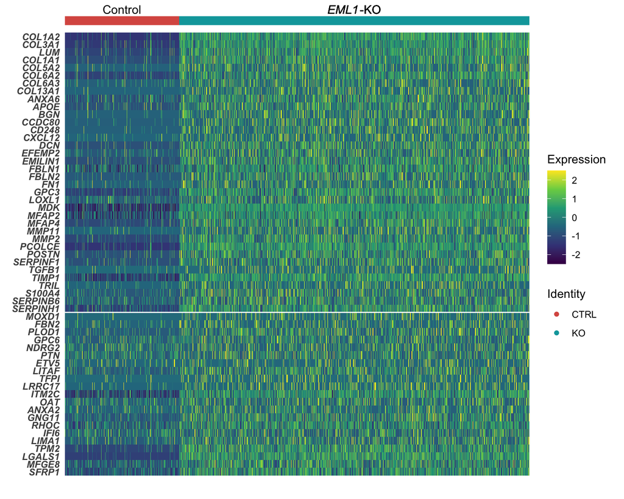

```r
DoHeatmap(RGtobRG, features = genes, group.colors = c("#DA5B51", "#00A5AA"), label = FALSE,
    draw.lines = FALSE) + scale_fill_viridis_c(option = "viridis") + theme(axis.text.y = element_text(face = "bold.italic")) +
    geom_hline(yintercept = c(21.5), color = "white") + annotate("text", x = 220,
    y = 60.5, label = "Control") + annotate("text", x = 1114, y = 60.5, label = substitute(paste(italic("EML1"),
    "-KO")))
```

# 4 Figure S4

```r
my_levels <- c("RG1", "RG to bRG", "RG2", "IP", "YN")
genes <- c("YAP1", "TEAD2", "CCND3", "CYR61")
Idents(data_subset) <- "cell_type"
Idents(data_subset) <- factor(Idents(data_subset), levels = my_levels)
sub_list <- map(my_levels, ~subset(data_subset, cell_type == .x))
for (i in seq_along(sub_list)) {
    Idents(sub_list[[i]]) <- "KO"
}

m <- map(sub_list, ~FindMarkers(object = .x, ident.1 = "KO", ident.2 = "CTRL", features = genes,
    logfc.threshold = 0, min.pct = 0))
names(m) <- my_levels
```

```r
m <- map2(my_levels, m, ~cbind(.y, cell_type = .x))
m <- map(m, ~cbind(.x, gene = rownames(.x)))
m_df <- rbind(m[[1]], m[[2]], m[[3]], m[[4]], m[[5]])
for (i in seq_along(m_df$p_val_adj)) {
    if (m_df$p_val_adj[i] < 0.001) {
        m_df$label[i] <- "***"
    } else if (m_df$p_val_adj[i] < 0.01) {
        m_df$label[i] <- "**"
    } else if (m_df$p_val_adj[i] < 0.05) {
        m_df$label[i] <- "*"
    } else {
        m_df$label[i] <- "ns"
    }
}
```

```r
# Stats
m_df
```

```
##               p_val    avg_logFC pct.1 pct.2    p_val_adj cell_type  gene label
## CCND3  3.012652e-04  0.068881657 0.179 0.128 1.000000e+00       RG1 CCND3    ns
## CYR61  3.116126e-04 -0.084229793 0.504 0.571 1.000000e+00       RG1 CYR61    ns
## TEAD2  2.612633e-01  0.023302000 0.588 0.560 1.000000e+00       RG1 TEAD2    ns
## YAP1   4.358211e-01  0.024023490 0.313 0.295 1.000000e+00       RG1  YAP1    ns
## TEAD21 1.227903e-26  0.320938354 0.856 0.747 2.630904e-22 RG to bRG TEAD2   ***
## CCND31 1.274112e-08  0.129992583 0.262 0.134 2.729911e-04 RG to bRG CCND3   ***
## CYR611 4.344047e-07  0.454789694 0.526 0.433 9.307556e-03 RG to bRG CYR61    **
## YAP11  1.533686e-06  0.143771330 0.458 0.367 3.286076e-02 RG to bRG  YAP1     *
## CCND32 1.561599e-01 -0.008875603 0.123 0.172 1.000000e+00       RG2 CCND3    ns
## CYR612 4.121269e-01  0.094523432 0.335 0.318 1.000000e+00       RG2 CYR61    ns
## TEAD22 5.215644e-01  0.046543227 0.654 0.677 1.000000e+00       RG2 TEAD2    ns
## YAP12  5.785037e-01  0.041278666 0.378 0.385 1.000000e+00       RG2  YAP1    ns
## YAP13  2.490088e-02  0.084659257 0.265 0.096 1.000000e+00        IP  YAP1    ns
## CCND33 1.854987e-01  0.065603989 0.118 0.048 1.000000e+00        IP CCND3    ns
## CYR613 4.167802e-01  0.053399602 0.235 0.157 1.000000e+00        IP CYR61    ns
## TEAD23 7.453995e-01  0.021871090 0.265 0.241 1.000000e+00        IP TEAD2    ns
## TEAD24 4.868034e-02  0.129473981 0.331 0.257 1.000000e+00        YN TEAD2    ns
## CCND34 2.518747e-01  0.068821738 0.108 0.080 1.000000e+00        YN CCND3    ns
## CYR614 3.902078e-01 -0.010069389 0.074 0.097 1.000000e+00        YN CYR61    ns
## YAP14  4.678763e-01  0.003971777 0.052 0.038 1.000000e+00        YN  YAP1    ns
```

```r
p <- vector("list", 4)

p[[1]] <- VlnPlot(data_subset, features = genes[1], split.by = "KO", pt.size = 0,
    split.plot = TRUE) + scale_fill_manual(values = c("#DA5B51", "#00A5AA"), labels = c("Control",
    substitute(paste(italic("EML1"), "-KO")))) + theme(axis.title.x = element_blank(),
    axis.ticks.x = element_blank(), plot.title = element_text(face = "bold.italic")) +
    annotate("text", x = c(1:5), y = max(GetAssayData(data_subset, slot = "data")[genes[1],
        ]) + max(GetAssayData(data_subset, slot = "data")[genes[1], ]) * 0.1, label = c("ns",
        "*", "ns", "ns", "ns"), size = c(4, 7, 4, 4, 4)) + ylim(-0.1, max(GetAssayData(data_subset,
    slot = "data")[genes[1], ]) + max(GetAssayData(data_subset, slot = "data")[genes[1],
    ]) * 0.15)
p[[2]] <- VlnPlot(data_subset, features = genes[2], split.by = "KO", pt.size = 0,
    split.plot = TRUE) + scale_fill_manual(values = c("#DA5B51", "#00A5AA"), labels = c("Control",
    substitute(paste(italic("EML1"), "-KO")))) + theme(axis.title.x = element_blank(),
    axis.ticks.x = element_blank(), plot.title = element_text(face = "bold.italic")) +
    annotate("text", x = c(1:5), y = max(GetAssayData(data_subset, slot = "data")[genes[2],
        ]) + max(GetAssayData(data_subset, slot = "data")[genes[2], ]) * 0.1, label = c("ns",
        "***", "ns", "ns", "ns"), size = c(4, 7, 4, 4, 4)) + ylim(-0.1, max(GetAssayData(data_subset,
    slot = "data")[genes[2], ]) + max(GetAssayData(data_subset, slot = "data")[genes[2],
    ]) * 0.15)
p[[3]] <- VlnPlot(data_subset, features = genes[3], split.by = "KO", pt.size = 0,
    split.plot = TRUE) + scale_fill_manual(values = c("#DA5B51", "#00A5AA"), labels = c("Control",
    substitute(paste(italic("EML1"), "-KO")))) + theme(axis.title.x = element_blank(),
    axis.ticks.x = element_blank(), plot.title = element_text(face = "bold.italic")) +
    annotate("text", x = c(1:5), y = max(GetAssayData(data_subset, slot = "data")[genes[3],
        ]) + max(GetAssayData(data_subset, slot = "data")[genes[3], ]) * 0.1, label = c("ns",
        "***", "ns", "ns", "ns"), size = c(4, 7, 4, 4, 4)) + ylim(-0.1, max(GetAssayData(data_subset,
    slot = "data")[genes[3], ]) + max(GetAssayData(data_subset, slot = "data")[genes[3],
    ]) * 0.15)
p[[4]] <- VlnPlot(data_subset, features = genes[4], split.by = "KO", pt.size = 0,
    split.plot = TRUE) + scale_fill_manual(values = c("#DA5B51", "#00A5AA"), labels = c("Control",
    substitute(paste(italic("EML1"), "-KO")))) + theme(axis.title.x = element_blank(),
    axis.ticks.x = element_blank(), plot.title = element_text(face = "bold.italic")) +
    annotate("text", x = c(1:5), y = max(GetAssayData(data_subset, slot = "data")[genes[4],
        ]) + max(GetAssayData(data_subset, slot = "data")[genes[4], ]) * 0.1, label = c("ns",
        "**", "ns", "ns", "ns"), size = c(4, 7, 4, 4, 4)) + ylim(-0.1, max(GetAssayData(data_subset,
    slot = "data")[genes[4], ]) + max(GetAssayData(data_subset, slot = "data")[genes[4],
    ]) * 0.15)
(p3 <- wrap_plots(p, ncol = 2) + plot_layout(guides = "collect")) & theme(legend.position = "bottom")
```

[figure not shown]